# Can We Trust Russian Public Opinion Surveys?

### 8e. The structural test: predicting one pollster from the other’s marginals

A still-stricter version of the cross-pollster test: take *only* Levada’s published aggregate marginals (the public press-release numbers, no microdata) plus the pre-war covariance structure of Russian survey responses, and use them to simulate Levada-style microdata for the wartime period. Then ask: can this simulated dataset predict an *independent* pollster’s monthly Putin-approval rate?

That is what `levadaSim V11` does. It simulates 80,000 wartime synthetic Levada respondents calibrated to Levada’s wartime press releases. None of the inputs include any VTsIOM data. We compare the simulation’s monthly approval rate to VTsIOM Sputnik’s monthly approval rate (real microdata, phone mode, ~50,000 respondents per month).

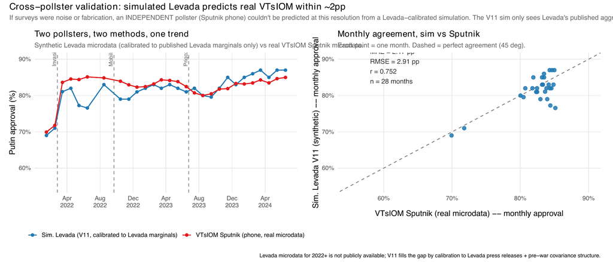

Figure 52. Cross-pollster validation: simulated Levada microdata predicts real VTsIOM Sputnik monthly approval within ~2pp.

Across 28 overlapping months (Jan 2022 – Jun 2024), the mean absolute error is **2.17 percentage points** and the Pearson correlation is **0.75**. This is the benchmark of what right looks like under cross-pollster convergence: if surveys were dominated by SDB, fabrication, or noise, two independent pollsters using different modes (F2F vs phone) and different sponsors (independent vs state-tied) wouldn’t agree at this resolution from independent data. They do.

The two modest discrepancies that remain are interesting on their own: in May–June 2022 the simulation runs ~7 points *below* Sputnik (Sputnik captured a slightly higher post-invasion peak than Levada’s published numbers); in early 2024 the simulation runs ~2–3 points *above* Sputnik. These are real differences between Levada and VTsIOM, not artefacts of the simulation. The lesson is that cross-pollster agreement is not perfect agreement on levels — it is agreement on direction, magnitude of change, and event-response. That is the agreement you’d expect from two real instruments, each with its own measurement quirks.

### 8f. Five instruments, one trajectory — and the published numbers match the raw data

The cleanest version of the cross-pollster argument puts everything on one chart. The figure below plots Putin approval from 2018 to 2026 across five instruments: VTsIOM’s daily Sputnik phone survey (microdata), VTsIOM’s *published* weekly topline, Levada’s face-to-face microdata (which ends in 2020), the academic online PROPA panel (2024–2025), and a second state-tied firm, FOM (2025–2026).

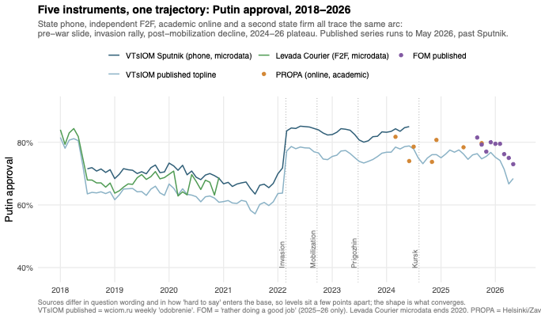

Figure 54. Putin approval across five instruments, 2018–2026 (VTsIOM Sputnik microdata, VTsIOM published topline, Levada Courier microdata, PROPA online, FOM published).

Every instrument traces the same arc: the pre-war slide, the invasion rally, the post-mobilization decline, and a 2024–2026 plateau. The lines sit a few points apart because they handle “hard to say” differently and word the question differently — but the *shape* is common to all of them. Crucially, the published series runs to **May 2026**, well past Sputnik’s June 2024 endpoint, so we can see the post-2024 period that no high-frequency microdata covers; PROPA (online) and FOM (a different state firm) anchor that gap independently.

One pairing in that figure deserves its own panel, because it speaks directly to the fabrication charge and to the changes-vs-levels argument at once. VTsIOM publishes a weekly headline approval number. We can also compute approval *ourselves* from the Sputnik microdata VTsIOM releases. If the state pollster were massaging its public numbers, the two would drift apart.

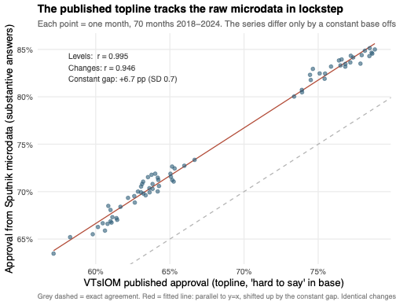

Figure 54b. VTsIOM’s published topline vs. the approval rate computed from its own microdata, monthly 2018–2024.

They don’t drift apart. The two series correlate at **r = 0.995** across 70 months and agree on month-to-month *changes* at **r = 0.95**. They differ only by a near-constant ~7-point level offset (standard deviation of the gap: 0.7pp), which comes entirely from the denominator: the published “odobrenie” counts “hard to say” in the base, while our microdata rate is computed over substantive answers. This is the whole “changes vs levels” point in a single picture: two versions of the same series can disagree about the *level* by a fixed amount while agreeing almost exactly about every *move*. The published headline isn’t being cooked relative to the raw data — and even if you distrust its level, its changes are trustworthy.

## 9. The Mode Effect: F2F vs Telephone vs Online

### 9a. Comparing five methodologies

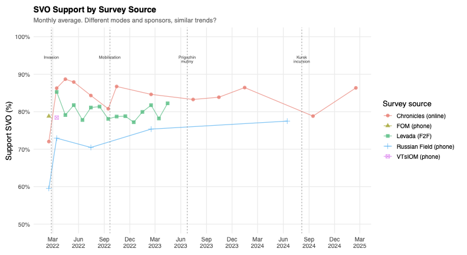

Figure 5a. War survey support by source over time.

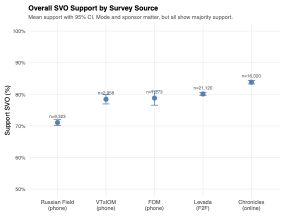

Figure 5b. War survey support: cross-source comparison.

### 9b. The Chronicles paradox

Online surveys (Chronicles), which should have the *least* SDB (no interviewer, maximum anonymity), actually show the *highest* support levels. This is the opposite of what the fear hypothesis predicts.

### 9c. What multi-point scales reveal

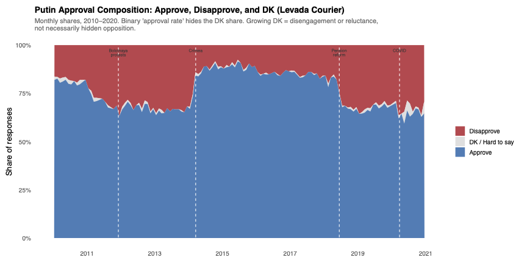

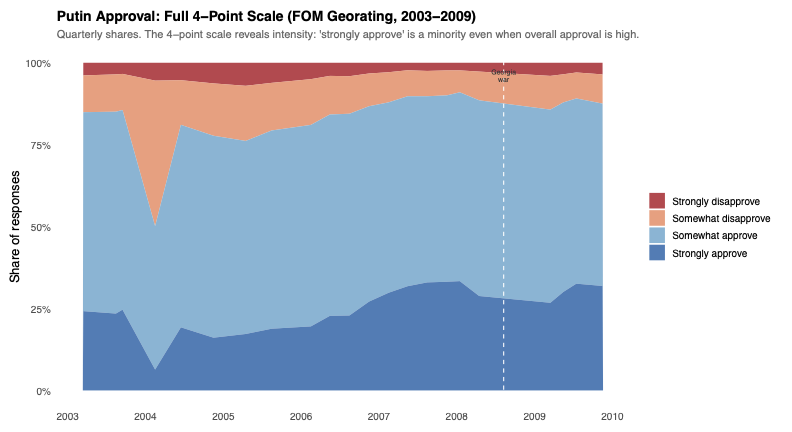

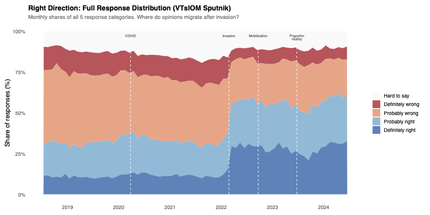

Figure 11. VTsIOM Sputnik “right direction” breakdown by response category.

The composition of approval is revealing. “Strong” approval is a minority. The majority of approvers are in the weak/conditional category — consistent with conformism rather than genuine enthusiasm.

### 9d. Adding online: the PROPA panel as an independent check

PROPA is a 5-wave online panel run by University of Helsinki researchers (Margarita Zavadskaya and colleagues) from March 2024 through October 2025. It is non-Russian-government, online (so any “interviewer fear” channel is at its weakest), and fields a broad battery of questions including Putin approval, war support, peace preferences, and perceived political environment.

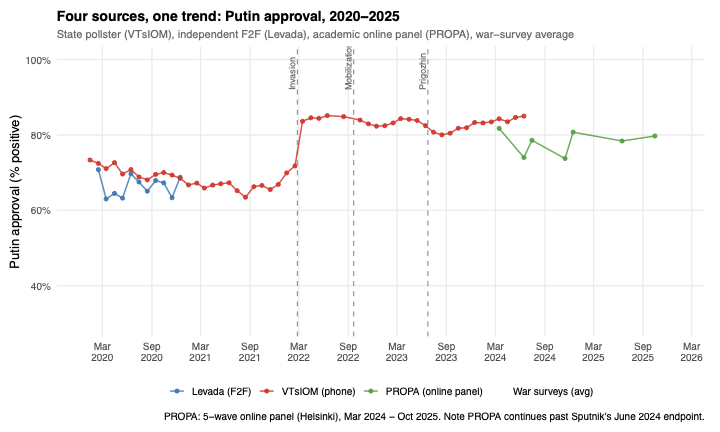

Figure 46. Cross-source approval convergence: state pollster (VTsIOM Sputnik), independent F2F (Levada), academic online panel (PROPA), 2020-2025. PROPA continues past Sputnik’s June 2024 endpoint.

The PROPA series sits roughly where you would expect given the other two: a few points below VTsIOM’s phone series (consistent with smaller mode effects from interviewer absence), broadly tracking the post-mobilization decline through 2025. The agreement isn’t perfect — PROPA’s online sample skews younger and more urban than F2F or phone — but it is in the ballpark, and crucially it covers the post-Sputnik period (Sputnik ends June 2024) where we otherwise have no high-frequency Russian data.

If Levada and VTsIOM were both compromised by SDB, fabrication, or political pressure, an independent academic online survey wouldn’t reproduce the same trajectory. It does.

The DK pattern is also informative:

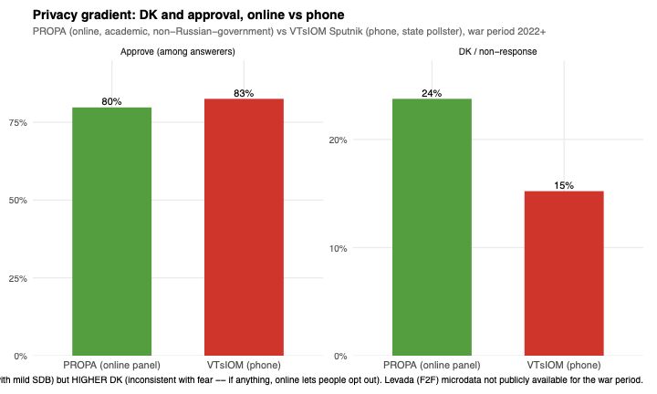

Figure 50. DK and approval by survey mode: PROPA online vs VTsIOM phone, war period 2022+.

PROPA’s online mode produces a slightly *lower* approve rate (80% vs VTsIOM’s 83%) and a substantially *higher* DK rate (24% vs 15%). The lower approve in the most-private mode is consistent with mild SDB on the order of a few percentage points — exactly the magnitude list experiments suggest. But the higher DK in the most-private mode is the *opposite* of what pure-fear SDB predicts: if respondents were afraid to give honest answers in person, online they’d opt to disapprove rather than opt to skip. The pattern instead points to disengagement: when respondents have an easy “don’t know” exit, more of them take it.

### 9e. The social-pressure mechanism: pluralistic ignorance

If SDB is mostly conformism rather than fear, what is the conformism *to*? PROPA asks panelists about their own Putin approval, their estimate of how their close social circle feels about Putin, and their estimate of how Russia as a whole feels about him. The three measures together let us see the social-pressure mechanism directly.

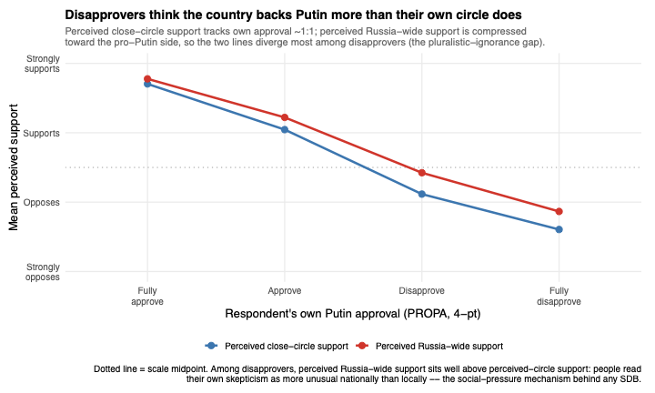

Figure 49. Disapprovers think the country backs Putin more than their own circle does. PROPA, all waves with the full battery.

The pattern is a textbook (if subtle) form of pluralistic ignorance. Respondents’ estimates of their *close-circle* support track their own approval almost 1:1: people who like Putin think their friends like Putin, people who dislike him think their friends dislike him. Estimates of *Russia-wide* support also rise with own approval — but they are compressed toward the pro-Putin side, so the two lines diverge most among disapprovers. A strong disapprover reads their own social circle as clearly anti-Putin, yet pegs the country as markedly more supportive than that circle (the gap between the two perceptions is about +0.3 on the 4-point scale, versus near zero for approvers). In other words: disapprovers know dissent exists around them, but believe it is more local and more unusual than it nationally is.

This is the social-pressure mechanism behind any SDB that exists. People stay quiet not mainly because they fear the police, but because they believe their disagreement is more idiosyncratic than it is. The result is a public conversation that overstates the depth of pro-regime sentiment, and a population that under-detects the prevalence of its own quiet skepticism. The same mechanism is what makes the “shallow support” finding in Section 10 sustainable: it is psychologically easy to give a “supportive” answer while privately disagreeing, *as long as you believe your disagreement is unusual*.

## 9½. Geographic Variation: The Smoking Gun for Real Sampling

If the data were fabricated or if fear made everyone give the same answer, we’d expect no geographic variation — or random noise. Instead, we see exactly the patterns a political scientist would predict.

### Settlement size matters

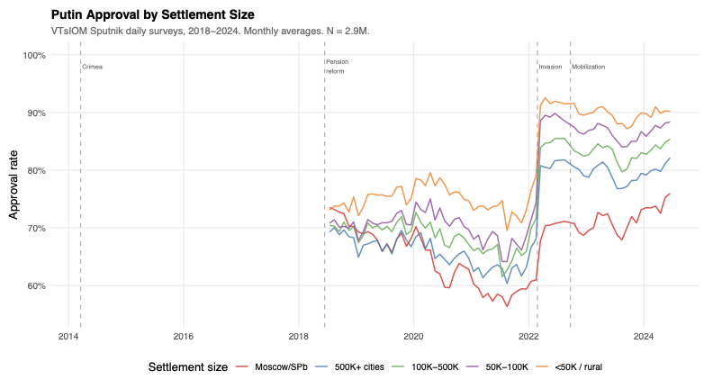

Figure 23. Putin approval by settlement size (VTsIOM Sputnik, 2018-2024, N = 2.9M).

### Rally dynamics by settlement size

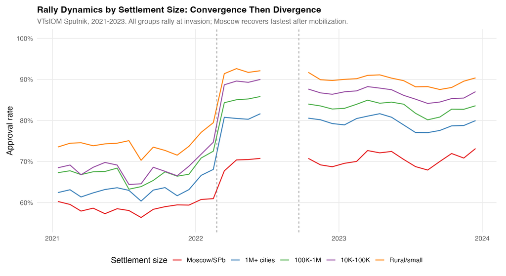

Figure 41. Rally dynamics by settlement size: convergence then divergence (VTsIOM Sputnik, 2021–2023).

The monthly time series by settlement size reveals a nuanced pattern. At invasion, all five groups rally sharply — but the *gap* between Moscow/SPb and rural areas actually *widens* during the war (from 14pp pre-war to 22pp in early wartime). Moscow and large cities show the most muted rally and the fastest recovery toward pre-war levels, while rural areas rally hardest and stay elevated longest. This is the opposite of what a uniform fear effect would produce.

### The war rally hits everywhere

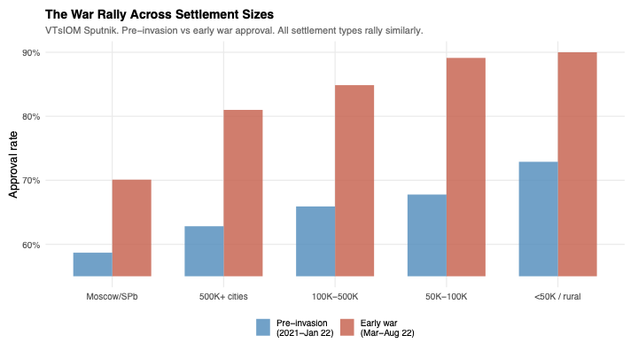

Figure 28. Pre-invasion vs early war approval by settlement size (VTsIOM Sputnik).

### Select regions tell individual stories

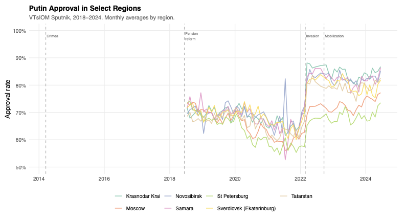

Figure 24. Putin approval in select regions (VTsIOM Sputnik, 2018-2024).

### The gender gap: persistent and predictable

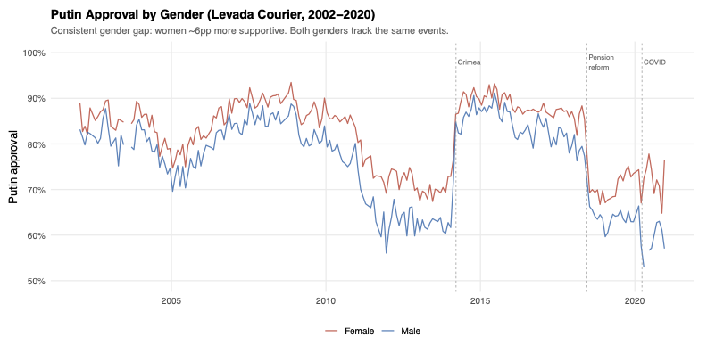

Figure 30. Putin approval by gender (Levada Courier, 2002-2020, N = 367K).

Women are consistently ~6 percentage points more supportive of Putin than men across 18 years of Levada data. Both genders track the same events — Crimea rally, pension reform dip, everything — at the same timing but different levels. This is a well-known finding in Russian public opinion research (older women are the core base of support), and its consistency across hundreds of survey waves is evidence that the sampling is real and stable. A fabricator would need to maintain this gap precisely, including its temporary narrowing during rallies (when men catch up) and widening during declines.

### Urban vs rural: the long view

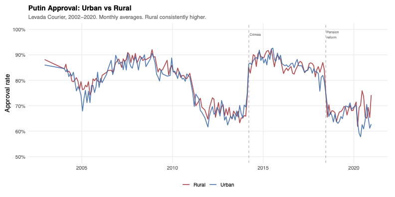

Figure 27. Putin approval: urban vs rural (Levada Courier, 2002-2020).

### DK rates don’t follow a fear gradient

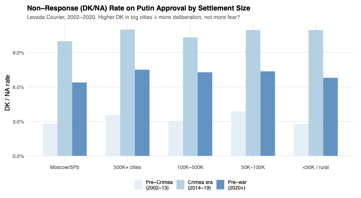

Figure 26. DK/NA rate on Putin approval by settlement size (Levada Courier, 2002-2020).

If fear drove non-response, we’d expect big-city respondents (who have more access to information about repression, more opposition media exposure) to refuse to answer more often. Instead, DK rates are fairly uniform across settlement sizes, and Moscow/SPb actually has slightly *lower* DK rates than other categories. The big story is the temporal pattern: DK jumped from ~3% to ~10% in the Crimea era everywhere, then partially declined. This looks like a national-level shift in engagement, not geographically targeted fear.

## 10. The Consistency Test: How Deep Is Support?

Headline numbers tell you that ~75% of Russians “support” the war. But what does that support actually mean? When the same respondents are asked multiple war-related questions, a striking pattern emerges: simultaneous majorities hold contradictory positions.

### 10a. The “two majorities”

Using Russian Field survey waves with multi-item war batteries (waves 8, 11, and 15, pooled N ≈ 5,200), we can cross-tabulate four key items:

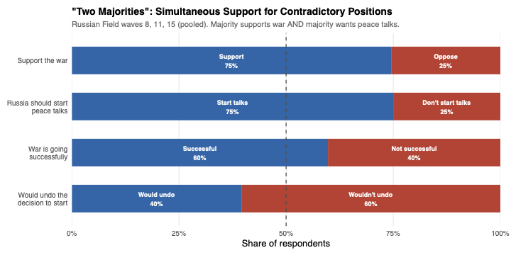

Figure 44a. Simultaneous majorities: support for contradictory positions.

The paradox is immediate. **75% say they support the war. 75% say Russia should start peace talks.** A majority says the war is going successfully (60%), while a large minority (40%) would undo the decision to start it entirely.

These are not just different people — the overlap is massive. Among the 75% who “support” the war, 68% also want peace talks, 19% would undo the decision to start the war, and a third would end it now if they could.

### 10b. What the conformist middle looks like

Breaking down positions on each war item by whether respondents support, oppose, or declined to answer the direct support question reveals the internal structure of public opinion:

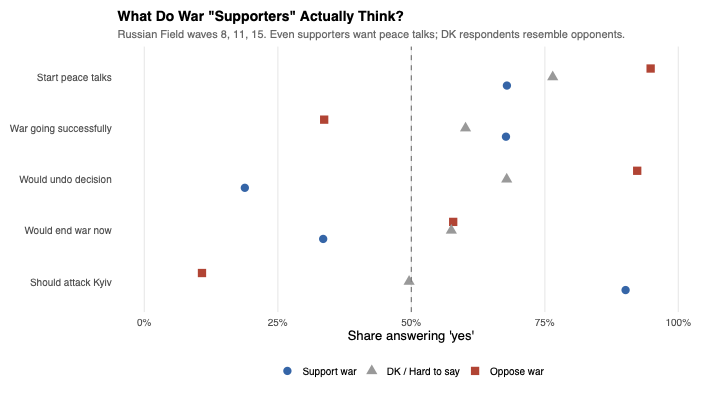

Figure 44b. Consistency profile: what war “supporters” actually think.

Several patterns stand out:

- **Even supporters want peace talks.** 68% of those who say “I support the war” also say Russia should start peace talks. This is not opposition in disguise — it’s shallow, conditional support coexisting with fatigue and a desire for resolution.
- **DK respondents resemble opponents.** On nearly every item — undo the decision (68% yes), end the war now (58%), attack Kyiv (50%) — those who declined to answer the support question look more like opponents than supporters. This is consistent with the DK demographic findings (Section 6): DK is disproportionately young, male, urban, and educated.
- **Very few are consistent hawks.** In the richest single wave (RF wave 11, N = 2,000), we classified respondents using four items: support the war, wouldn’t undo, war going successfully, and oppose peace talks. Among those with complete data, **only 3.2% are consistent hawks.** 73.7% are “soft supporters” — they say they support the war but hold at least one dovish position. 17.3% are consistent doves, and 5.8% are mixed opponents.

The headline “75% support” is not wrong, but it is deeply misleading about what Russians actually want. As Minyaylo (2022) puts it, the support number is a “mass grave” that lumps together true believers, passive conformists, and people who said “yes” because it was the easiest thing to say. The consistency test digs up what’s underneath.

### 10c. What this means for SDB

The consistency pattern is not just descriptively interesting — it directly distinguishes between the two competing mechanisms for SDB.

**If fear drives SDB**, we would expect *high* consistency. A respondent who strategically lies about supporting the war to avoid repercussions would also suppress dovish answers on other items to maintain their cover story. Strategic liars think about cross-item logic. Fear-based SDB should produce more consistent hawks, not fewer.

**If conformism/disengagement drives SDB**, we would expect *low* consistency. A respondent who gives quick surface-level “safe” answers without thinking about internal logic will independently endorse whatever seems acceptable on each item. Crucially, both “I support the war” and “Russia should start peace talks” can feel like “safe” answers — the government’s own position has frequently included openness to talks. Conformism doesn’t coordinate across items.

The observed 3.2% consistent hawks strongly favors conformism over fear. We can formalize this with the Fake Russia Generator (Section 11).

### 10d. How deep is support? It depends on the question

The consistency test above runs on Russian Field’s wave 11, where the peace item is *soft*: “should Russia start peace talks?” — a question you can answer “yes” while still supporting the war. Ask it that way and the overlap is huge. But the size of the overlap turns out to be extremely sensitive to wording, and that sensitivity is itself the lesson.

The figure below takes everyone who says they support the war and asks what share *also* hold each dovish position, ordered from the softest framing to the hardest:

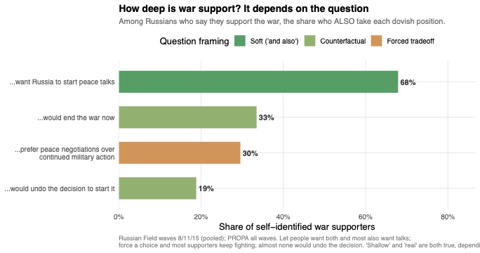

Figure 55. Among self-identified war supporters, the share who also take each dovish position, by question framing (Russian Field + PROPA).

When people are allowed to want both things, most do: 68% of supporters also want peace talks. But when PROPA forces a genuine *tradeoff* — “peace negotiations **over** continued military action” — only **30%** of the same self-identified supporters pick peace. And when asked the strongest counterfactual — would you *undo* the decision to start the war? — just **19%** say yes. Support looks shallow under the soft framing and solid under the hard one. Both numbers are real; they answer different questions.

The PROPA panel makes the same point from the approval side. It asks Putin approval on a 5-point Levada-style scale and the forced peace-or-fighting tradeoff in the same instrument:

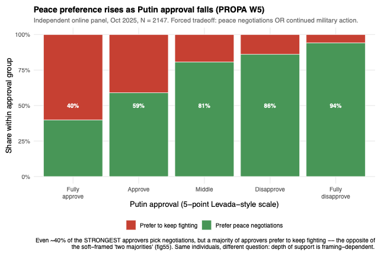

Figure 48. Peace preference rises monotonically as Putin approval falls (PROPA wave 5, forced tradeoff). Independent online panel, October 2025.

Here the relationship is a clean *negative* gradient: among the strongest approvers, only ~40% choose negotiations over fighting; among the strongest disapprovers, 94% do. (This corrects an earlier version of this analysis that had the approval scale reversed and reported the opposite.) Under a forced tradeoff, approval and dovishness pull apart — the opposite of the soft-framed “two majorities.” Same individuals, different question.

So which is it — shallow or solid? Both. The honest summary is that wartime Russian support is **wide but thin**: most people will endorse the war and *also* endorse ending it, and which impulse a poll captures depends on whether it lets them have both. That is not a flaw in the surveys; it is a real property of the opinion, and it is exactly why a single headline number — in either direction — misleads.

## 11. The Fake Russia Generator

### 11a. The idea

What if we could build a Russia from scratch? We know the demographics. We can set the “true” level of support to anything we want. Then we can add different amounts and types of SDB, apply realistic survey sampling, and see what comes out. If 10% SDB produces data that looks like reality, and 30% doesn’t, that tells us something.

### 11b. Three scenarios

We test three theoretical positions by building synthetic Russias under each set of assumptions:

1. **Mild SDB (~5pp):** The Levada defense. True support is close to measured support. Small bias from conformism and fear, bounded by list experiment estimates.
2. **Extreme skeptic (30% true support):** Only ~40% truly approve of Putin, but massive fear-driven SDB pushes measured approval to ~52%. This scenario *cannot produce the ~80% approval we actually observe* without implausible assumptions.
3. **Disengagement (shallow conformism):** True support is real but shallow. Low SDB, high DK rates. People give quick answers and move on.

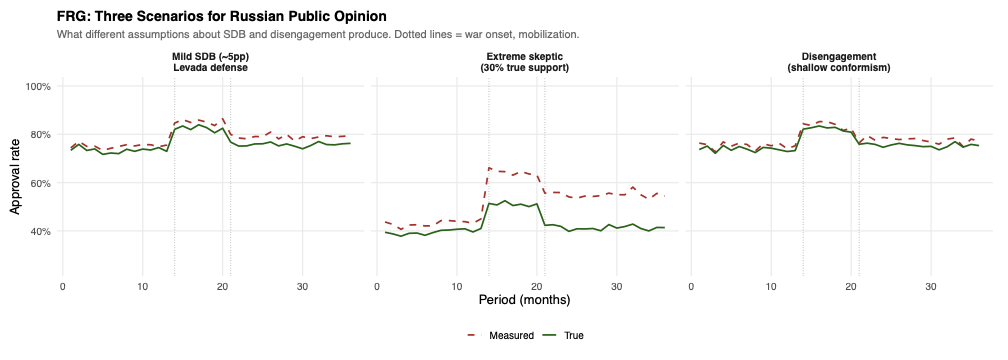

Figure 20a. FRG: Three scenarios — true vs measured approval.

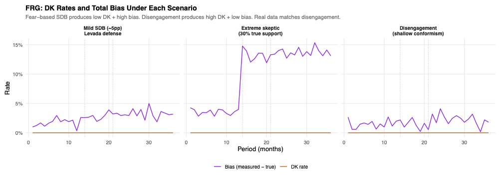

Figure 20b. FRG: DK rates and total bias under each scenario.

### 11c. The consistency test: fear vs conformism

The consistency findings from Section 10 give us something rare: an empirical test that directly distinguishes between SDB mechanisms. We extend the FRG to simulate multi-item war attitudes (support, peace talks, success assessment, undo preference) under two models:

- **Fear-based SDB:** Respondents who falsify their answers do so *consistently* across all items, maintaining a coordinated hawkish cover story. If you lie about supporting the war, you also lie about opposing peace talks.
- **Conformism-based SDB:** Respondents conform *independently* on each item, pushing toward whatever feels like the “safe” answer. Crucially, for peace talks, the safe answer (“yes, start talks”) *conflicts* with the hawkish position (“no talks”) — because the Russian government has itself signaled openness to negotiations.

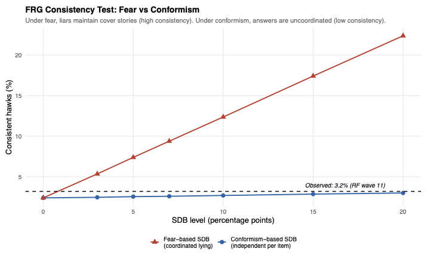

Figure 45. FRG consistency test: fear vs conformism. Observed consistency strongly favors the conformism model.

The result is unambiguous. Under fear-based SDB, consistent hawks rise sharply with SDB level — from 2.4% at baseline to 7.4% at 5pp SDB and 22% at 20pp SDB. Afraid liars maintain their cover stories, producing artificially coherent hawkish positions. Under conformism, consistent hawks barely budge from the baseline (~2.5–3%) regardless of how much SDB is applied, because the independent per-item conformism pushes don’t coordinate across items.

The observed 3.2% consistent hawks in Russian Field wave 11 sits squarely on the conformism line. Even at 20pp of conformism-based SDB — far more than list experiments suggest — the consistency rate stays below 3.5%.

The marginals tell the same story. Under fear at 10pp SDB, peace talks support *falls* to 64% (people afraid to express any dovish position). Under conformism at 10pp SDB, peace talks support *rises* to 73% — matching the observed 75%. The fear model gets both the consistency rate and the marginals wrong. The conformism model matches both.

This doesn’t prove fear plays zero role. Some respondents are undoubtedly afraid. But the dominant mechanism producing the gap between true and measured attitudes is not coordinated strategic lying — it’s shallow, uncoordinated conformism that doesn’t survive cross-item scrutiny.

## 12. Beyond Surveys: What Russians Search, Say, and Do

### 12a. Yandex Wordstat: What Russians search for

Yandex Wordstat captures what Russians actually search for online — a behavioral signal that’s harder to fake than a survey response. We track three groups of search terms: emigration/relocation, anti-war/draft avoidance, and pro-war/SVO terms.

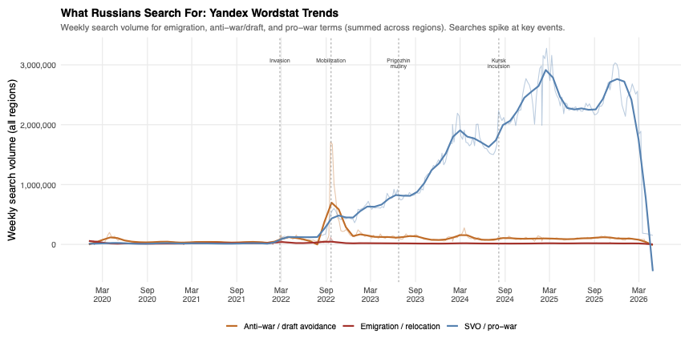

Figure 21a. Yandex Wordstat: search volume for emigration, anti-war, and pro-war terms (2020-2025).

### 12b. Do searches track survey attitudes?

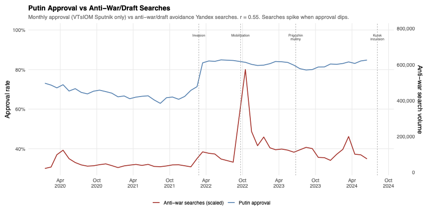

Figure 21b. Putin approval vs anti-war/draft searches (dual axis).

Anti-war searches and approval don’t move in perfect opposition — the relationship is more complex than “searches reveal hidden opposition.” Both spike at the same events (invasion, mobilization), suggesting the searches capture genuine shock and information-seeking, not just covert dissent. The key insight: search behavior is *consistent with* the survey data, not contradictory.

### 12b½. The geographic test: do maps match?

The strongest validation comes from matching survey attitudes to search behavior *across regions*. If surveys capture something real, regions where approval is lower should also be regions where people search more for emigration and anti-war terms.

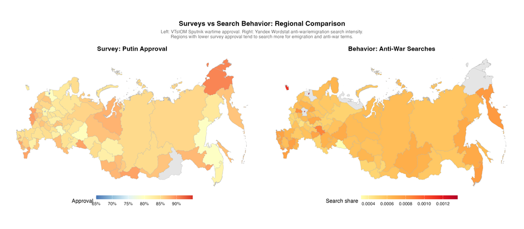

Figure 37. Side-by-side: regional Putin approval vs anti-war search intensity (77 regions).

Moscow and St Petersburg show the lowest survey approval AND the highest anti-war search volume — a convergence across completely independent measurement systems.

A fair objection: maybe this is just regional *structure* — richer, more urban, less authoritarian regions are both less supportive and more search-prone, so the two measures share confounders rather than corroborating each other. They don’t. Regressing regional approval on the search index *plus* GRP per capita, urbanization, unemployment, and a regional democracy score, the search coefficient stays large and highly significant (b = −0.24, *p* < 0.001), and the partial correlation is **−0.57** across 78 regions. (The search index here is within-phrase z-scored so it isn’t dominated by passport searches.)

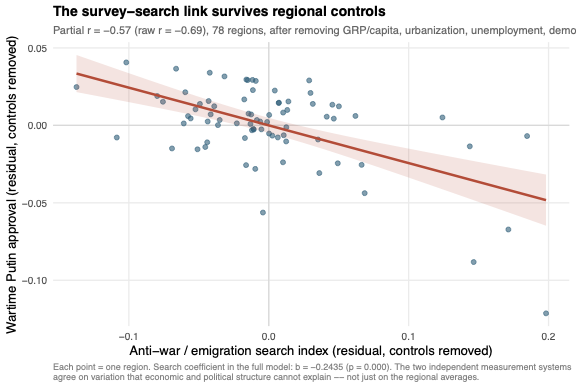

Figure 57. The survey–search correlation survives regional controls: approval vs. search after residualizing both on economic and political structure.

The two measurement systems agree on variation that economic and political structure cannot explain — which is exactly what genuine cross-validation looks like, and exactly what shared confounding would not produce.

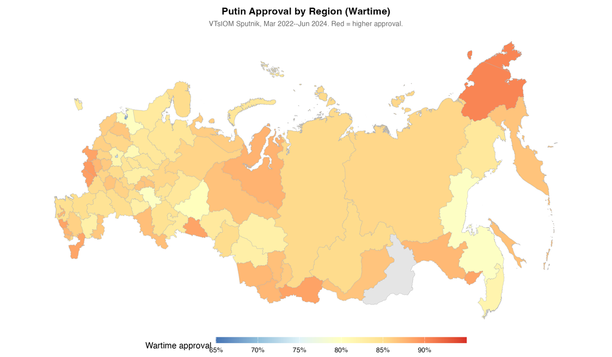

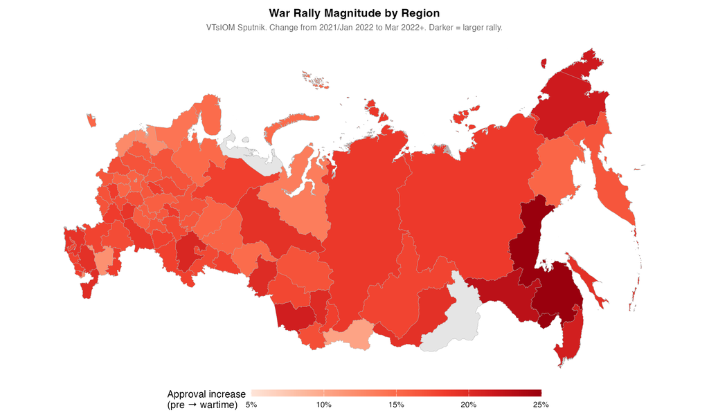

Figure 38. War rally magnitude by region. Darker = larger approval increase from pre-war to wartime.

The rally map (Figure 38) shows that the war effect was genuinely national — every region rallied — but with meaningful variation. Peripheral and rural regions show the largest jumps, while Moscow, St Petersburg, and other major urban centers had more moderate rallies. This geographic heterogeneity in *both levels and changes* is strong evidence of real sampling.

### 12b¾. The event-level test: do search and survey move together at war shocks?

The geographic correlation in 12b½ is a *level* test: where approval is low, search activity is high. We can also run a *time* test: at specific war shocks, does survey approval move at the same time that search behavior does? Two independent measurement channels responding to the same exogenous event in real time would be hard to fake.

We pick three events with the cleanest signature in both data sources — the invasion (Feb 24, 2022), mobilization (Sep 21, 2022), and the Prigozhin mutiny (Jun 24, 2023) — and compare weekly Sputnik approval to weekly Yandex search shares for event-relevant baskets (sanctions / VPN / “how to leave Russia” for the invasion; “when will mobilization happen” / “how to avoid the draft” / “leave Russia” for mobilization; Prigozhin name searches plus VPN/escape for the mutiny).

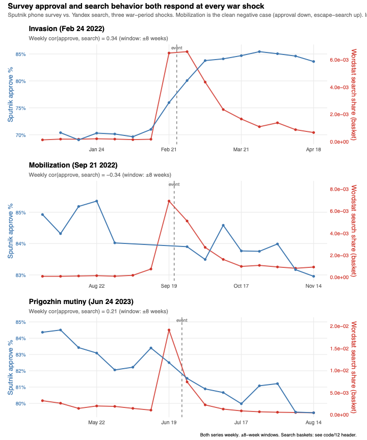

Figure 51. Survey approval and search behavior both respond at every war shock. Sputnik phone survey vs. Yandex search, three war-period shocks, ±8 weeks.

[figure not shown]

Figure 51b. Pooled correlation across three shocks (within-event z-scored).

Pooled across all three events, the within-event correlation between approval and search is essentially zero (r = 0.09, n = 44 weeks). The correct interpretation is not “search and surveys disagree” — they don’t, both respond at every event — but rather “the nature of the response depends on the shock.” This is the opposite of what we’d expect from a fabricated or fear-driven instrument, which would produce either flat-lined approval or uniform “rally” responses regardless of context.

### 12c. A channel that didn’t hold up: social-media audience mood

There is a third behavioral channel one would like to use: the *tone* of what Russians say to each other on regional Telegram, scored with a sentiment model (RuBERT) and pooled into a national daily “audience-mood” index. An earlier draft of this piece reported a strong positive correlation between that mood index and survey approval (r ≈ 0.80, 30-day rolling) and presented it as a third converging signal.

It does not hold up, and the honest thing is to say so. On the current, expanded social-media data — across the comment, post, and emoji-reaction variants of the index — the correlation with survey approval is near zero or even negative. And it collapses entirely the moment you do the very test the earlier draft said was “the right follow-up”: first-difference both series to strip out the shared downward trend, and the co-movement essentially disappears (changes-correlation ≈ 0 across every variant). The original 0.80 was mostly two series drifting down together over a short overlapping window — precisely the levels-vs-changes trap this piece warns about, now caught biting our own analysis. (The sentiment pipeline is also mid-rebuild, with a 2023–2024 coverage gap.)

So this channel is filed under “tested, didn’t pan out.” That is worth stating plainly, both because honesty about negative results is the whole point of an exercise like this, and because it is a useful caution: a high *level* correlation between two trending series is weak evidence on its own. The behavioral channels that *do* validate the survey signal are search (Section 12b), which moves at the right events, and cross-pollster convergence (Sections 8e–8f), which is strong on both levels and changes. Social-media mood is a candidate to revisit once its underlying data stabilize.

## 13. Putting It All Together

### 13b. What we don’t know

- The exact magnitude of SDB on war questions specifically (vs Putin approval generally)
- Whether the composition of non-response has changed in ways we can’t detect
- What “support” means in the minds of the conformist majority
- Whether independent behavioral signals beyond search (social-media tone, VK discussion) corroborate the surveys — the mood channel we tried (§12c) did not survive scrutiny on current data

### 13c. The bottom line

Russian surveys are imperfect — like all surveys everywhere. The 72% headline number overstates the depth of conviction. But dismissing the data entirely is itself a form of ignorance, and it leads to worse analysis than taking the data seriously while understanding its limitations.

The surveys are telling us something real: a society that is not in revolt, not enthusiastically pro-war for the most part, but deeply conformist, disengaged, and — yes — genuinely shaped by decades of propaganda. That’s not a comforting conclusion. But it’s probably the right one.

## Appendix A: List Experiment Estimates

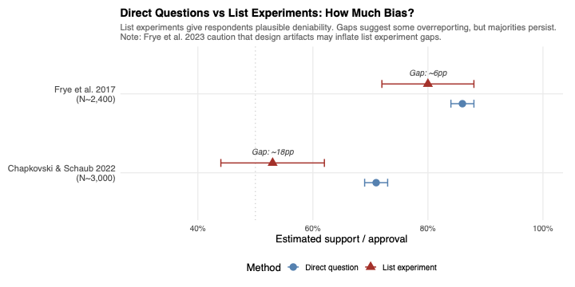

Figure 16. List experiment estimates: direct vs indirect questioning gap.

## Appendix B: Approval by Age Group

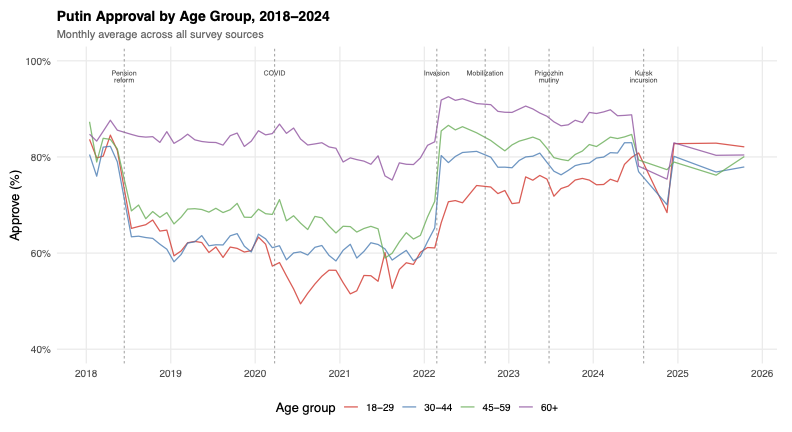

Figure 3. Putin approval by age group over time.

## Appendix C: Is the Data Even Real? Testing the Fabrication Hypothesis

A small but vocal group argues that the data itself is fabricated — that interviewers fill in responses without conducting interviews, or that organizations manipulate results before publication. This is a serious charge that deserves testing, even if the evidence ultimately doesn’t support it.

### Digit tests: stability as evidence

If someone were fabricating survey data — whether interviewers filling in fake responses or an organization manipulating results — we’d expect to see it in the statistical fingerprints of the data. One approach: examine the distribution of terminal digits in reported ages.

The key insight is not whether the distribution shows heaping (it does — respondents worldwide round their own ages to 0 and 5). The question is whether the digit pattern *changes* in ways that suggest manipulation. If fabrication increased during wartime, or if different survey firms fabricate differently, the digit distributions should diverge.

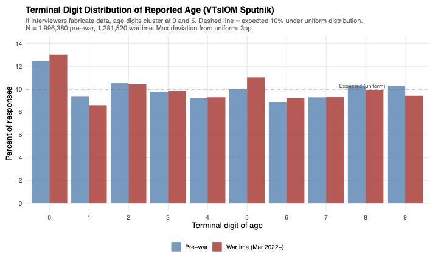

Figure 22. Terminal digit distribution of reported age (VTsIOM Sputnik): pre-war vs wartime.

The results: pre-war and wartime digit distributions are virtually identical. The mild “0” heaping (12.7% vs expected 10%) is the classic age-rounding pattern seen in all surveys worldwide. If fabrication were increasing during wartime, we’d see divergence between the two distributions. We don’t.

[NOTE: Future iterations will expand this to cross-survey digit comparisons (Levada vs VTsIOM), response entropy analysis, and other numeric variables.]

### Event responsiveness as validation

Real data shows micro-level responses to events that a fabricator wouldn’t know to include. The mobilization dip, Prigozhin wobble, and Kursk response all appear in the daily Sputnik data within hours of the events occurring. A fabricator would need to anticipate these events and calibrate the exact magnitude of response — across age groups, regions, and settlement sizes simultaneously.

### Cross-pollster convergence

If multiple firms produce convergent demographic gradients (Section 8c), fabrication requires a conspiracy spanning independent organizations with different institutional incentives.

## Appendix D: Methodology and Data Documentation

*This appendix provides detailed documentation of data sources, analytical decisions, simulation mechanics, and calibration procedures. It is intended as a reference for replication and methodological transparency, not as required reading.*

### D1. Survey data sources

All survey microdata used in this piece comes from the `surveyData/` harmonization infrastructure, which standardizes variables across surveys into a common format. Key harmonized variables include `approve_putin` (binary: 1 = approve, 0 = disapprove), `rightdir` (country heading in right direction), demographic identifiers (age, gender, education, urban/rural, settlement size, region), and survey metadata (source, wave, date, mode).

**Levada Courier (1992–2022).** Monthly face-to-face surveys of ~1,600 adults in the Russian adult population, conducted by the Levada Center (formerly the All-Russian Center for Public Opinion Research, VTsIOM-A). Stratified multi-stage probability sampling with quotas by age and gender within primary sampling units. The microdata covers approximately 424,000 individual survey responses across ~270 waves. Fieldwork is typically conducted in the last week of each month. Raw data is in SPSS (.sav) format, read via R’s `haven` package. The last available microdata wave is late 2020; wartime Levada data exists as published aggregates but microdata has not been released. Weights are applied where available (`qVEC` for pre-2017 waves, `qVECTOR` for 2019+). Putin approval is coded from the standard Levada question (“Do you approve or disapprove of the activities of Vladimir Putin as President of Russia?”) with a four-point response scale (fully approve / rather approve / rather disapprove / fully disapprove / hard to say). The binary `approve_putin` collapses the first two categories.

**FOM Georating (2003–2011).** Large-scale regional face-to-face surveys conducted by FOM (Public Opinion Foundation), with ~34,000 respondents per wave across all 82 Russian regions. Total harmonized dataset: 977,000 observations. Used primarily for the four-point approval composition analysis (Figure 18b) and as an independent cross-pollster comparison source. FOM is organizationally distinct from both Levada and VTsIOM.

**War surveys (2022–2024).** Five independent survey operations covering the wartime period, harmonized into a common dataset of ~83,000 observations:

- *Levada* (F2F, ~1,600/wave): The standard Levada monthly survey, continued during wartime. Available as published aggregates.
- *VTsIOM Sputnik* (telephone, ~1,600/day): Continuous daily data through June 2024.
- *Russian Field* (telephone RDD, variable sample sizes): Independent pollster using random-digit dialing. Wave 11 (February 2023, N ≈ 2,000) includes unique meta-questions about survey fear. Wave-specific variables (`survey_fear`, `svo_fear_privatedisc`, `protest_ready_safe`) are accessed from source files rather than the harmonized dataset.
- *FOM* (F2F, various): Public Opinion Foundation wartime waves.
- *Chronicles* (online panel, variable N): Self-selected online panel survey. Expected to show least SDB due to maximum anonymity; counterintuitively shows highest support levels, consistent with a self-selection effect among engaged, patriotic internet users.

**Afina/Bessudnov survey (February 28–March 1, 2022).** Independent multi-agency telephone survey with 1,642 completed interviews from 27,751 contact attempts (5.9% completion rate). Contains unique interviewer-assessed respondent openness variable (Q306: three-point scale). The SPSS file requires the `memisc` R package for reading due to 1,501 empty-named string continuation records that crash `haven`, `foreign`, and `pyreadstat`. Variables are stored as Russian text labels requiring pattern-matching extraction.

**PROPA panel survey (March 2024).** Online panel survey conducted around the March 2024 presidential election (N ≈ 4,800). Contains a list experiment for war support — the primary source for the ~6–10pp SDB bound cited throughout the piece.

### D2. Non-survey data sources

**Yandex Wordstat.** Weekly search frequency data from Yandex (Russia’s dominant search engine, ~60% market share) for 170 search phrases, covering 2018–September 2025, across Russian regions. Data file contains ~14.8 million rows. Search terms are organized into thematic groups: emigration/relocation (e.g., “как уехать из России,” “загранпаспорт”), anti-war/draft avoidance (e.g., “как избежать мобилизации,” “уехать от армии”), and pro-war/SVO terms. Data stored at `~/Dropbox/Data/wordstat_protest_data/`. Regional crosswalk available for matching to survey regionid.

**VK communities.** 2,341 local VK (VKontakte) community groups across 85 Russian regions, sampled from a HuggingFace dataset of 222 million VK groups (CC0 license). Groups include local discussion forums (“подслушано”), news communities, school/education groups, and incident-reporting channels. 14–28 groups per region. Scraping in progress at time of writing.

**Regional Telegram channels.** 955 channels across 85 Russian regions, ~745,000 posts. Used for potential sentiment analysis and event detection. Data available but analysis pending.

### D3. Variable construction and coding decisions

**Putin approval (binary).** The harmonized `approve_putin` variable collapses four-point and five-point scales into binary (approve/disapprove), treating “hard to say” / DK as missing. This is the standard approach in the literature and matches published Levada/VTsIOM aggregate figures. Multi-point composition is analyzed separately where noted (Figures 18, 18b).

**DK/non-response rates.** DK rates are computed as the proportion of contacted respondents who give a “hard to say,” “don’t know,” or explicit refusal response, out of all respondents (including those who gave substantive answers). DK is coded from the original survey instruments, not from missing values in the harmonized data (which may also include item-level skip patterns). DK extraction from raw SAV files uses coded values: DK=9 for Levada Courier, DK=99 for VTsIOM Sputnik.

**Settlement size.** Five categories used throughout: Moscow/SPb (population 10M+), cities over 1 million, 100K–1M, 10K–100K, and rural/small towns (<10K). These are VTsIOM’s standard classification. Levada uses a slightly different classification that is harmonized to the same five categories where possible.

**Age groups.** Standard four-group classification: 18–29, 30–44, 45–59, 60+. These boundaries are conventional in Russian survey research and roughly correspond to post-Soviet, late-Soviet, mid-Soviet, and early-Soviet cohorts.

**War support (SVO).** Measured from March 2022 onward using the question “Do you support the special military operation in Ukraine?” Available from all five wartime survey sources with varying response scales, harmonized to binary support/oppose.

### D4. The Fake Russia Generator: simulation design

The FRG is an agent-based simulation that generates synthetic survey data under user-specified assumptions about true attitudes and social desirability bias. Two implementations exist: a full R script (`01_fake_russia_generator.R`) and a simplified interactive Shiny app (`app/app.R`). The methodology description below covers both.

#### D4a. Population generation (full model)

A synthetic population of *N* = 100,000 individuals is generated with:

- **Demographics**: Age (Normal, μ=45, σ=17, truncated to 18–85), gender (46% male), education (4 categories with age-correlated probabilities), urban/rural (74% urban baseline with regional variation).
- **82 regions** with log-normal population sizes (creating a Moscow-like outlier) and region-specific random effects (Normal, σ=0.06).
- **TV viewership**: Binary variable, probability = f(age, education, urban), where older, less educated, and rural individuals are more likely to be TV-primary consumers. TV viewership feeds directly into true approval as a covariate.
- **Correlated latent traits**: Three latent traits — political awareness, regime trust, and conformism — are drawn from a multivariate normal distribution (via `MASS::mvrnorm()`) and transformed to [0,1] via the probit-beta copula. The correlation structure encodes theoretically motivated relationships: awareness is negatively correlated with trust (r = −0.20) and conformism (r = −0.15); trust and conformism are positively correlated (r = 0.30). These traits govern heterogeneous SDB and non-response behavior.

#### D4b. True latent attitudes

**Approval** is generated as a continuous latent variable on [0,1]:

`approval_i = b0 + a_region + b_age*(age - mean_age) + b_male*male + b_educ*(educ - 2.5) + b_urban*urban + b_tv*tv + noise`

Default parameters: β₀ = 0.62 (pre-war base), β_age = +0.004/year, β_male = +0.02, β_educ = −0.03/category, β_urban = −0.05, β_tv = +0.12, σ_ε = 0.22.

**War support** is a separate latent variable, correlated with approval (r = 0.70) but with distinct demographic effects (stronger age and gender gradients, separate rally/decay dynamics). Generated via a conditional normal model: war support = f(approval) + independent noise, where the residual SD is calibrated to produce the target correlation.

#### D4c. Time dynamics

The simulation covers 36 monthly periods (approximately January 2021 – December 2023). War onset occurs at period 14 (February 2022), mobilization at period 21 (September 2022). Shocks follow exponentially decaying impulse-response functions:

- **Rally effect**: +0.08 at war onset, decaying at 3% per month
- **Mobilization shock**: −0.04 overall, with an additional −0.02 for young men (age < 35, male = 1), decaying at 2% per month
- War support has its own rally (+0.10) and mobilization shock (−0.06, with −0.048 additional for young men)

#### D4d. Social desirability bias model

SDB is applied as an additive shift toward approval, with several components:

1. **Base SDB**: 0.02 pre-war, 0.05 wartime (constant across individuals)
2. **Trait-varying**: Awareness (+0.02), conformism (+0.04), trust (−0.02), age (−0.001/year), education (+0.01/category)
3. **Fear component** (in “fear” or “mixed” models): Proportional to repression awareness (30% pre-war, 50% wartime) × individual awareness × degree of disapproval
4. **Mode effect**: Multiplier on total SDB — F2F = 1.0, telephone = 0.8, online = 0.5
5. **Asymmetry**: SDB only affects individuals who disapprove (approvers have nothing to hide). SDB magnitude scales with degree of disapproval: `sdb × max(0, 1 − approval_true)`

The measured approval is: `min(1, approval_true + sdb_total)`

#### D4e. Multi-stage survey selection

Three selection stages introduce non-random attrition:

1. **Contact** (logistical): Base rate 60%, slightly lower in urban areas (−5pp). Independent of attitudes.
2. **Cooperation** (among contacted): Base rate 45%, increasing with age (+0.5pp/year), trust (+10pp), and regime approval (+2pp). Wartime drop of −2pp. This introduces mild pro-regime selection.
3. **Item non-response / DK** (among cooperating respondents): Base rate 5%, increasing for middling attitudes (+10pp for those near 0.50), wartime boost (+4pp), and aware opponents (+3pp × awareness). DK responses are excluded from the approval calculation, mimicking standard survey practice.

The resulting effective sample per wave is ~1,600 (matching Levada/VTsIOM design).

#### D4f. Measurement

Latent continuous approval is converted to categorical responses via cutpoints (0.30, 0.50, 0.70 for 4-category; 0.50 for binary), with additive measurement noise (σ = 0.05).

#### D4g. Simplified interactive model (Shiny app)

The Shiny app uses a simplified three-group model optimized for interpretability and real-time interaction:

- **Three groups**: Believers, apathetics, and opponents. User sets population shares (must sum to 100%).
- **Group-specific parameters**: Each group has fixed true approval probabilities (believers: 92% pre-war / 96% wartime; apathetics: 65% / adjustable; opponents: 12% / adjustable). Users control rally effects for apathetics and opponents.
- **Three SDB channels**: (1) Falsification — opponents and apathetics who truly disapprove “flip” to approval at user-set rates. (2) Non-response — opponents and apathetics refuse to participate at user-set rates, creating pro-regime selection. (3) DK — different groups give DK at different rates (apathetics 1.8×, opponents 1.5×, believers 0.3× the base rate).
- **Geography**: Five settlement sizes with demographic adjustments matching VTsIOM’s Sputnik data. Moscow/SPb residents are shifted toward opposition (+6pp opponent share, −6pp believer share); rural residents toward support.
- **SVO support**: Separate outcome with lower base rates (believers 82%, apathetics 45%, opponents 6%) and higher DK multipliers (1.5× approval DK for the overall rate).
- **Sample**: N = 8,000 simulated, 3,000 sampled per period, after removing refusals.

#### D4h. Benchmark calibration

The Shiny app compares simulated results against pre-computed benchmarks from real data:

| Benchmark | Source | Coverage | N |
| --- | --- | --- | --- |
| Overall approval (pre-war, wartime) | VTsIOM Sputnik | 2021–Jan 2022 vs Mar 2022+ | ~2.9M |
| Approval by settlement size | VTsIOM Sputnik | Same periods | ~2.9M |
| Approval by age group | Levada Courier | 2010–2022 | ~400K |
| DK rates by question type | Levada Courier | 2010–2022 | ~400K |
| SVO support by survey source | 5 sources | 2022–2024 | ~83K |

Benchmark values hardcoded in `app.R`: pre-war overall approval = 66.0%, wartime = 82.9%. Moscow/SPb wartime = 71.3%, rural wartime = 90.1%.

Benchmarks are extracted by `05_extract_benchmarks.R`, which loads the survey master dataset (5.2M observations) and Levada Courier microdata, computes period-specific means, and saves a compact RDS file (~few KB) read by the Shiny app at startup.

#### D4i. What is calibrated vs. assumed

| Parameter | Status | Source |
| --- | --- | --- |
| Demographic distributions (age, education, urban, settlement size) | **Calibrated** | Matched to VTsIOM Sputnik sample composition |
| Approval benchmarks (overall, by geography, by age) | **Calibrated** | Computed from survey microdata |
| DK rates by question type | **Calibrated** | Computed from Levada Courier microdata |
| True attitude base rates (believers/apathetics/opponents) | **User-set** | Interactive sliders; presets based on literature estimates |
| SDB magnitudes (falsification rates, lie boost) | **User-set** | Bounded by list experiment estimates (~6–10pp) |
| Non-response rates (refusal by group) | **User-set** | Informed by reported contact/cooperation rates |
| Rally effects | **User-set** | Magnitude informed by observed pre/post differences |
| Trait correlations (awareness, trust, conformism) | **Assumed** | Theoretically motivated; sensitivity analysis in full model |
| Group-specific approval probabilities | **Assumed** | Set to produce realistic baseline approval when combined |
| Geographic adjustment magnitudes | **Assumed** | Tuned to roughly match observed settlement-size gradient |
| SVO true support rates by group | **Assumed** | Set to produce realistic SVO support when combined with SDB |
| Fear/repression awareness parameters | **Assumed** | Loosely informed by legal data but not directly estimated |

### D5. Statistical methods

Most analyses in this piece are descriptive: time series, cross-tabulations, and group comparisons. No causal claims are made from the observational survey data alone. Specific methods:

**Cross-pollster coefficient comparison (Figure 15).** OLS regressions of `approve_putin ~ age + male + educ + urban` estimated separately on each survey source. Point estimates and 95% confidence intervals plotted side by side. Standard errors are heteroskedasticity-robust (HC1). The comparison tests whether demographic gradients are structurally similar across surveys, not whether any individual coefficient is statistically significant.

**Month-on-month changes correlation (Figure 17).** Monthly mean approval computed for Levada and VTsIOM separately. First differences (Δapproval_t = approval_t − approval_{t−1}) computed. Pearson correlation between the two change series reported. This tests whether the surveys track the same underlying signal in their dynamics, regardless of level differences.

**Digit analysis (Figure 22, Appendix C).** Terminal digit distribution of self-reported age computed separately for pre-war and wartime VTsIOM Sputnik observations. Chi-squared test of homogeneity between the two distributions. The null hypothesis is that the digit distribution is unchanged; rejection would suggest altered data collection or fabrication procedures.

**FRG scenario comparison.** For each preset scenario, 100 simulation runs are generated with different random seeds. Mean and 95% simulation intervals for approval, DK rates, and total SDB are reported. The comparison with observed data uses simple distance (|simulated − observed|) rather than formal statistical tests, since the simulation parameters are user-chosen rather than estimated.

### D6. Figures and reproducibility

All figures are generated by numbered R scripts in `sdb/code/`:

| Script | Figures | Description |
| --- | --- | --- |
| `01_fake_russia_generator.R` | 19a, 19b, 20a, 20b, 45 | FRG simulation scenarios + fear-vs-conformism consistency test |
| `02_time_series_plots.R` | 01–12 | Core time series and cross-source comparisons |
| `03_additional_plots.R` | 13a, 13b, 14–18, 18b | Demographics, list experiments, composition; cross-pollster coefficients (fig15, harmonized education) |
| `04_remaining_analyses.R` | 21a, 21b, 22 | Yandex Wordstat trends; terminal-digit fabrication test |
| `05_extract_benchmarks.R` | (none) | Benchmark data for Shiny app |
| `06_geographic_plots.R` | 23–28 | Settlement size, regions, urban/rural, DK geography |
| `07_subgroup_analyses.R` | 29, 29b, 30–33, 44a, 44b | Survey fear, gender, age×mobilization, protest, economic placebo, two-majorities |
| `08_afina_openness.R` | 34 | Interviewer-rated candor × war support (Afina) |
| `09_maps.R` | 35–38 | Regional choropleths: approval, search intensity, side-by-side, rally magnitude |
| `10_social_science_analyses.R` | 39–43 | Rally anatomy, DK leading indicator, rally by settlement size, DK demographics/sensitivity |
| `11_propa_analyses.R` | 46–50 | PROPA cross-source, within-person Δ, peace-by-approval, pluralistic ignorance, DK by mode |
| `12_sputnik_wordstat_events.R` | 51, 51b | Daily survey × search event windows |
| `13_levadasim_validation.R` | 52 | Simulated-Levada vs Sputnik cross-pollster validation |
| `15_pollster_topline.R` | 54, 54b | Multi-pollster convergence to 2026; published-topline vs microdata |
| `16_framing_depth_of_support.R` | 55 | Depth of war support by question framing |
| `17_weekremember_salience.R` | 56, 56b | Spontaneous open-ended salience (event-tracking + disengagement) |
| `19_regional_robustness.R` | 57 | Survey×search correlation, robust to regional covariates |

(`14_mood_approval_overlay.R` produced figs 53/53b, retired in this revision — see §12c. The interactive FRG lives in `app/app.R`.)

Figures are saved as both PDF (vector, for publication) and PNG (raster, for web) in `sdb/figures/` and `sdb/figures/png/` respectively.

The HTML report is built from `draft/report.md` using Pandoc:

```
quarto pandoc report.md -f markdown -t html5 --standalone --embed-resources -c report_style.css -o report.html
```

### D7. Limitations and caveats

**Microdata availability.** Levada Courier microdata ends in late 2020. Wartime Levada results are available as published aggregates but individual-level data has not been released. This means wartime analyses of Levada data rely on published tables rather than replicable microdata computations.

**Weighting.** Not all survey waves have proper design weights. Where weights are unavailable, unweighted means are reported. This primarily affects early Levada waves (pre-2010) and some VTsIOM Express data. All VTsIOM Sputnik analyses are unweighted (weights not provided in the Roper Center release); published VTsIOM aggregates use post-stratification weights and may differ slightly from our calculations.

**List experiment bounds.** The ~6–10pp SDB estimate is drawn primarily from a single list experiment (PROPA, March 2024) and cross-validated against Rosenfeld (2018) and Frye et al. (2017). List experiments have their own limitations: they assume no design effects (liars tell the truth in the list condition), and the PROPA sample is an online panel (not representative). The bound should be treated as an order-of-magnitude estimate, not a precise measurement.

**Selection on unobservables.** The FRG can model observable non-response (by demographics, regime attitudes, and latent traits), but real-world selection may operate on dimensions we cannot observe or simulate. If the people who refuse surveys are systematically different from participants in ways uncorrelated with our modeled traits, the simulation’s non-response channel may understate actual selection bias.

**Ecological inference.** Regional-level patterns (settlement size gradients, urban-rural gaps) are aggregate; they do not establish individual-level mechanisms. A city-level pattern of lower approval could reflect composition (more educated, younger residents) rather than a distinct “urban effect” on attitudes.

**Temporal coverage gaps.** The analysis relies most heavily on VTsIOM Sputnik (2018–2024) for high-frequency data and Levada Courier (1992–2020) for historical context. The period between late 2020 and mid-2022 has limited individual-level Levada data, creating a partial gap at the critical pre-war/wartime transition. War survey data from Russian Field, Chronicles, and others partially fills this gap but with different methodologies.

*Draft: June 2026 (rebooted from March 2026). Figures generated from code in `sdb/code/`. Data sources: Levada Courier (1992–2020 microdata), VTsIOM Sputnik (2018–2024), VTsIOM + FOM published toplines (1990–2026), FOM Georating (2003–2011), war surveys (2022–Feb 2026), PROPA online panel (2024–2025), VTsIOM “weekremember” (2011–2017), Yandex Wordstat.*